# State MSM Profile: **Arkansas**

### Background & Methods

In 2015-2016, researchers at Emory University partnered with colleagues at the Centers for Disease Control and Prevention (CDC) to develop methods to estimate the number of men who have sex with men (MSM) residing in each county in the United States. Using population and housing data from the [American Community Survey](https://www.census.gov/programs-surveys/acs/) and estimates from two peer-reviewed publications ([Oster et al., 2015](http://www.ncbi.nlm.nih.gov/pubmed/26115985) & [Purcell et al., 2012](http://www.ncbi.nlm.nih.gov/pubmed/23049658)), they derived an indirect estimate of MSM population sizes that took into account both the urbanicity of the county as well as its density of households with a male householder and a male same-sex partner.

The full methodology is published in the *Journal of Medical Internet Research - Public Health and Surveillance*:

> [Grey JA, Bernstein KT, Sullivan PS, Purcell DW, Chesson HW, Gift TL, Rosenberg ES. Estimating the population sizes of men who have sex with men in US states and counties using data from the American Community Survey. JMIR Public Health Surveill 2016;2(1):e14. DOI: 10.2196/publichealth.5365](http://publichealth.jmir.org/2016/1/e14/)

### Overview of MSM in Arkansas

An estimated **19,263** men who have sex with men (MSM) resided in Arkansas in 2013, representing 0.4% of the 4,503,084 MSM in the United States. Of the 1,076,736 adult men of Arkansas, 1.8% had had sex with another man in the past 5 years, which was less than the overall percentage of adult men in the United States who were MSM (3.9%).

Most MSM in Arkansas resided in counties within medium or small metropolitan areas (69.9%). Including both central and fringe counties, 1.7% resided in a large metropolitan area.

##### **Percentage of MSM by urbanicity, United States and Arkansas, 2013**

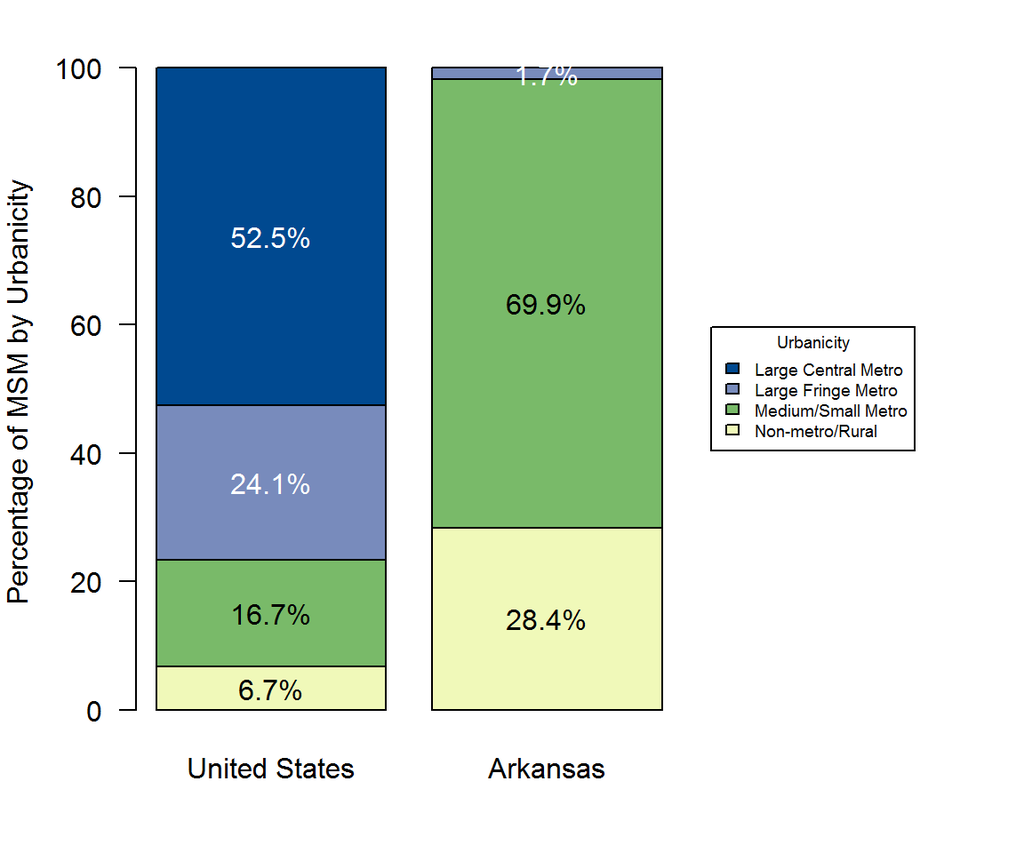

### MSM in Arkansas Counties

Among counties or county-equivalent areas in Arkansas, Pulaski County had the largest population of MSM at 3,483, representing 18.1% of all MSM in the state. Lincoln County had the highest percentage of MSM among adult men in Arkansas at 9.7%. This was greater than the percentage for Arkansas as a whole, which was 1.8% of adult men.

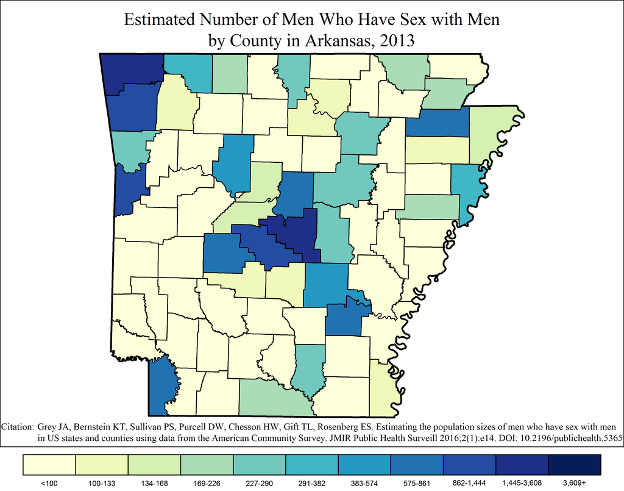

Note: Range cutpoints for the map are based on the distribution of MSM among all counties in the United States.

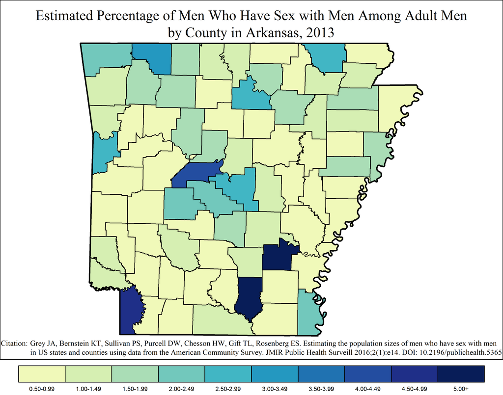

### MSM in Arkansas Metropolitan Statistical Areas

#### Little Rock-North Little Rock-Conway Metropolitan Statistical Area

The Little Rock-North Little Rock-Conway MSA had the largest metropolitan population of MSM in Arkansas at 5,531, or 28.7% of all MSM in the state. Of the 256,262 adult men in Little Rock-North Little Rock-Conway, an estimated 2.2% were MSM.

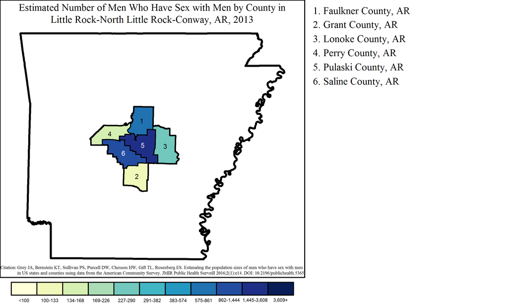

Note: Range cutpoints for the map are based on the distribution of MSM among all counties in the United States.

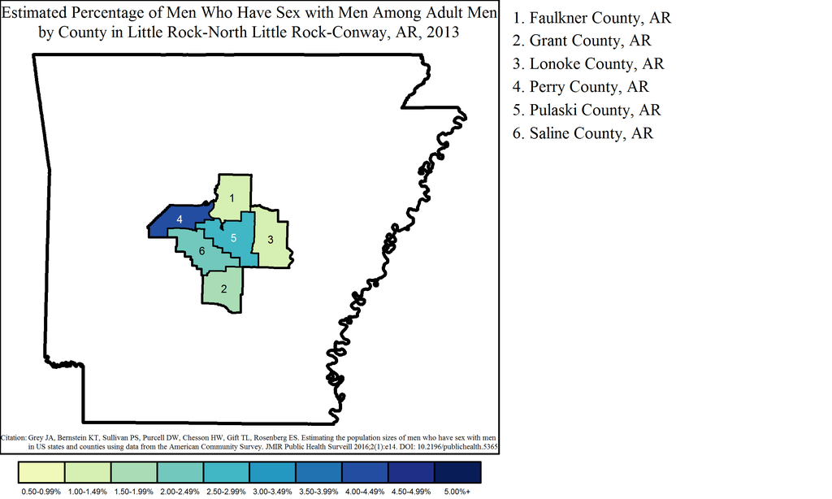

#### Fayetteville-Springdale-Rogers Metropolitan Statistical Area

The Fayetteville-Springdale-Rogers MSA overlaps two states: Arkansas and Missouri. The Arkansas portion of the MSA had 2,920 MSM, or 15.2% of all MSM in the state and 97.0% of the 3,010 MSM in the MSA. Of 163,458 adult men in the Arkansas part of Fayetteville-Springdale-Rogers, 1.8% were MSM. This was equal to the overall percentage of MSM among adult men in the MSA, which was 1.8% of adult men (3,010 out of 171,768).

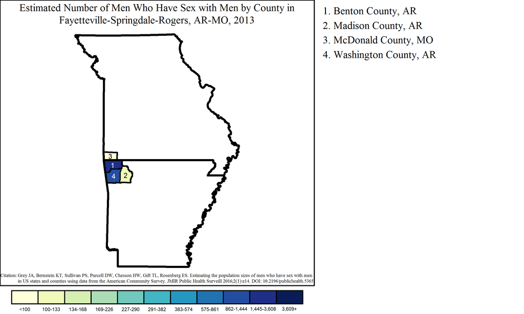

Note: Range cutpoints for the map are based on the distribution of MSM among all counties in the United States.

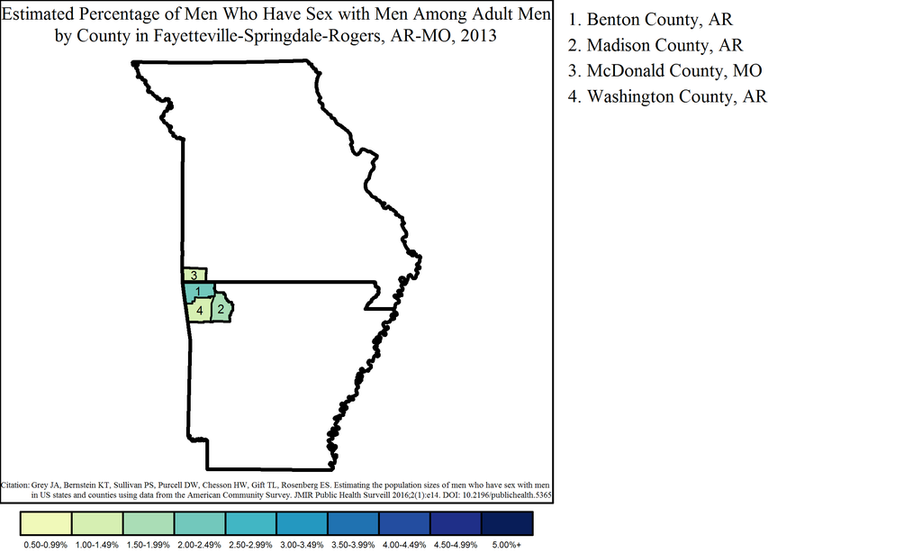

#### Fort Smith Metropolitan Statistical Area

The Fort Smith MSA overlaps two states: Arkansas and Oklahoma. The Arkansas portion of the MSA had 1,543 MSM, or 8.0% of all MSM in the state and 66.8% of the 2,310 MSM in the MSA. Of 67,953 adult men in the Arkansas part of Fort Smith, 2.3% were MSM. This was equal to the overall percentage of MSM among adult men in the MSA, which was 2.3% of adult men (2,310 out of 102,040).

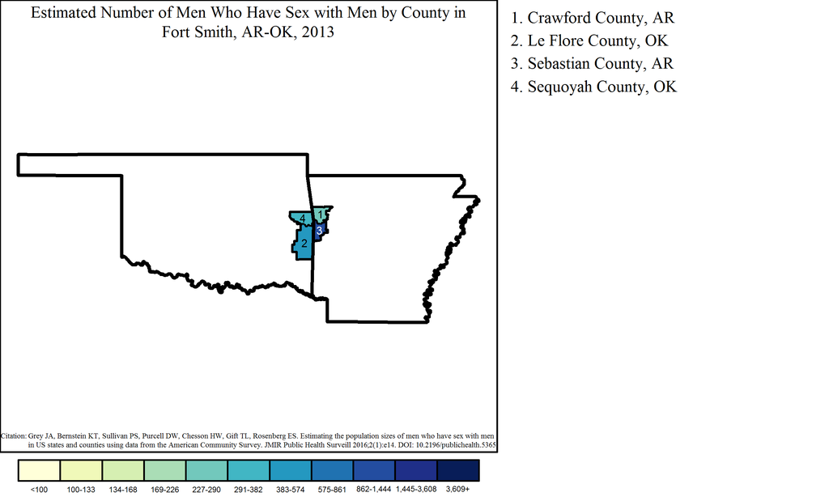

Note: Range cutpoints for the map are based on the distribution of MSM among all counties in the United States.

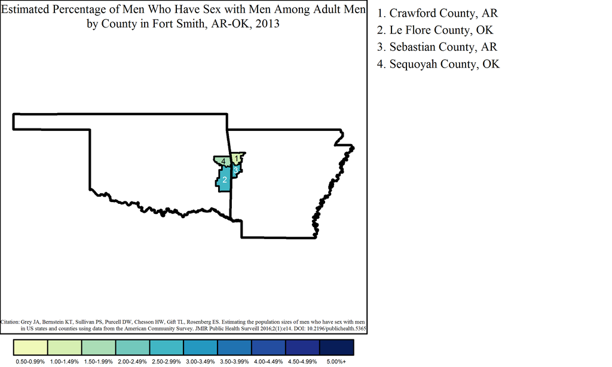

#### Pine Bluff Metropolitan Statistical Area

The Pine Bluff MSA had a population of 1,123 MSM, or 5.8% of all MSM in Arkansas. Of the 38,428 adult men in Pine Bluff, an estimated 2.9% were MSM.

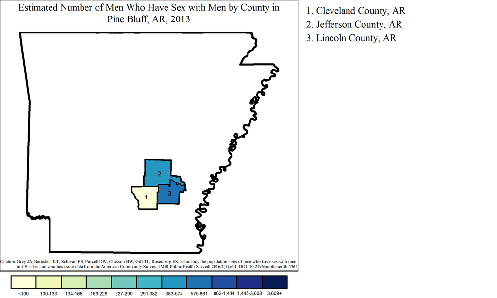

Note: Range cutpoints for the map are based on the distribution of MSM among all counties in the United States.

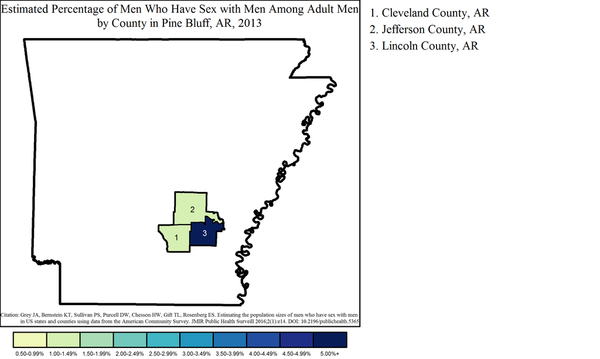

#### Hot Springs Metropolitan Statistical Area

The Hot Springs MSA had a population of 850 MSM, or 4.4% of all MSM in Arkansas. Of the 36,283 adult men in Hot Springs, an estimated 2.3% were MSM.

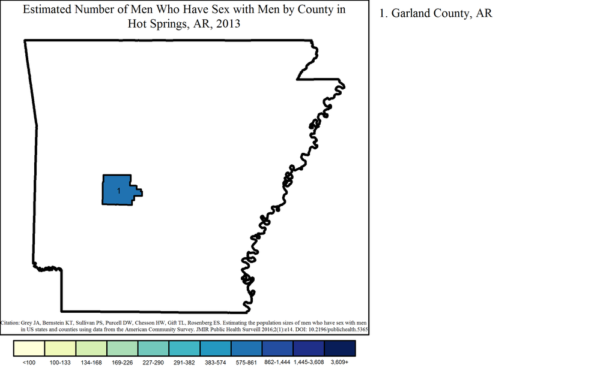

Note: Range cutpoints for the map are based on the distribution of MSM among all counties in the United States.

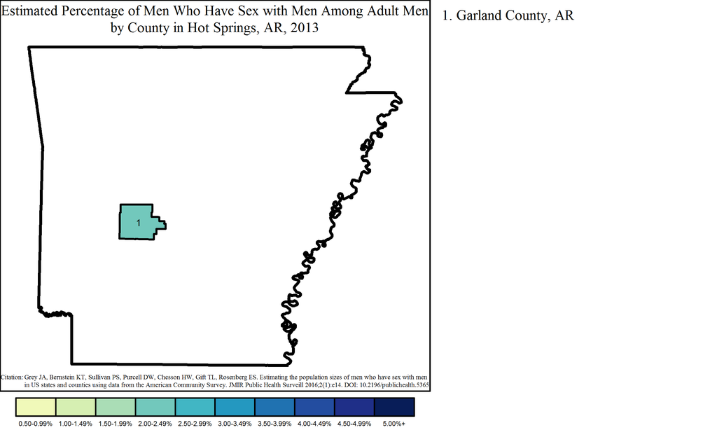

#### Texarkana Metropolitan Statistical Area

The Texarkana MSA overlaps two states: Arkansas and Texas. The Arkansas portion of the MSA had 793 MSM, or 4.1% of all MSM in the state and 66.4% of the 1,194 MSM in the MSA. Of 20,691 adult men in the Arkansas part of Texarkana, 3.8% were MSM. This was greater than the overall percentage of MSM among adult men in the MSA, which was 2.1% of adult men (1,194 out of 56,083).

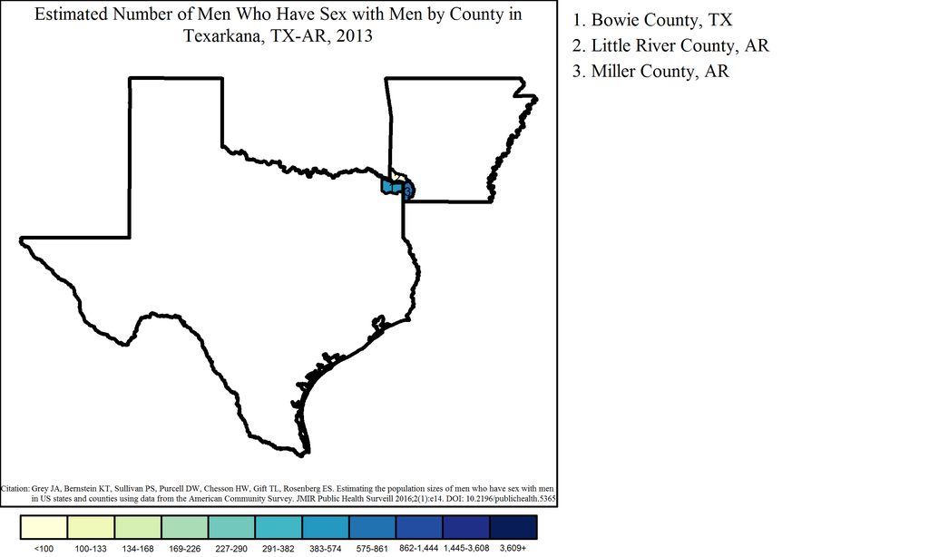

Note: Range cutpoints for the map are based on the distribution of MSM among all counties in the United States.

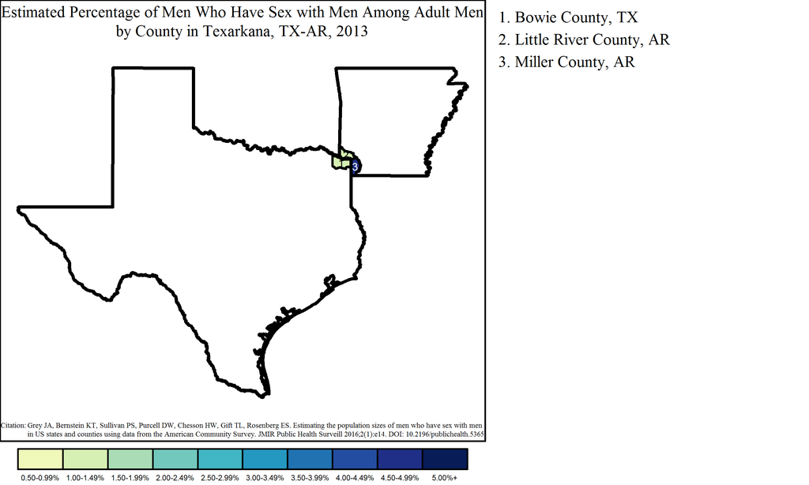

#### Jonesboro Metropolitan Statistical Area

The Jonesboro MSA had a population of 708 MSM, or 3.7% of all MSM in Arkansas. Of the 44,200 adult men in Jonesboro, an estimated 1.6% were MSM.

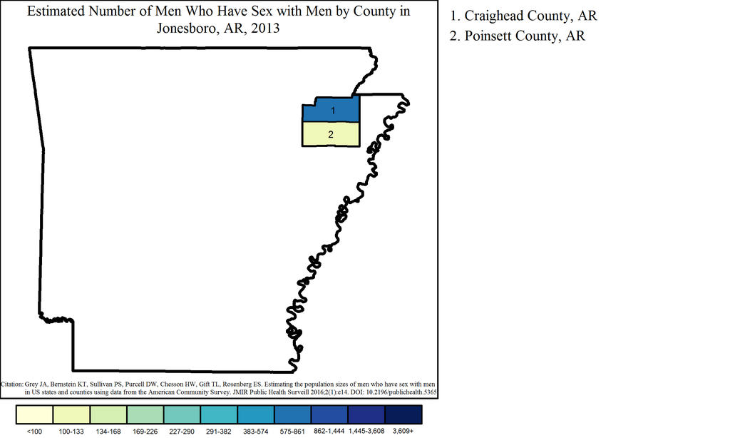

Note: Range cutpoints for the map are based on the distribution of MSM among all counties in the United States.

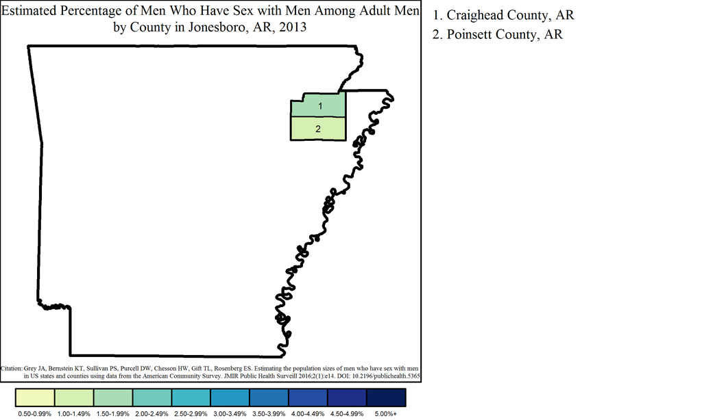

#### Memphis Metropolitan Statistical Area

The Memphis MSA overlaps three states: Arkansas, Mississippi and Tennessee. The Arkansas portion of the MSA had 332 MSM, or 1.7% of all MSM in the state and 1.5% of the 21,722 MSM in the MSA. Of 16,720 adult men in the Arkansas part of Memphis, 2.0% were MSM. This was less than the overall percentage of MSM among adult men in the MSA, which was 4.7% of adult men (21,722 out of 461,959).

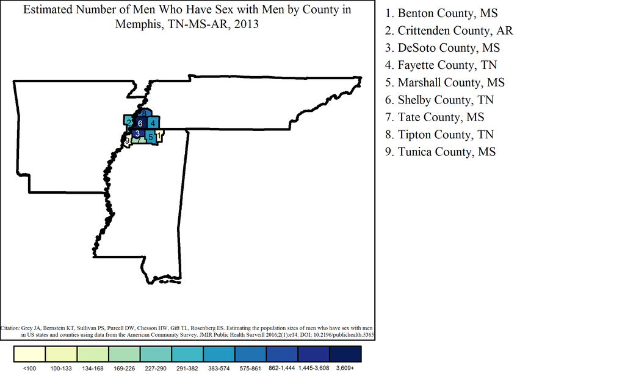

Note: Range cutpoints for the map are based on the distribution of MSM among all counties in the United States.

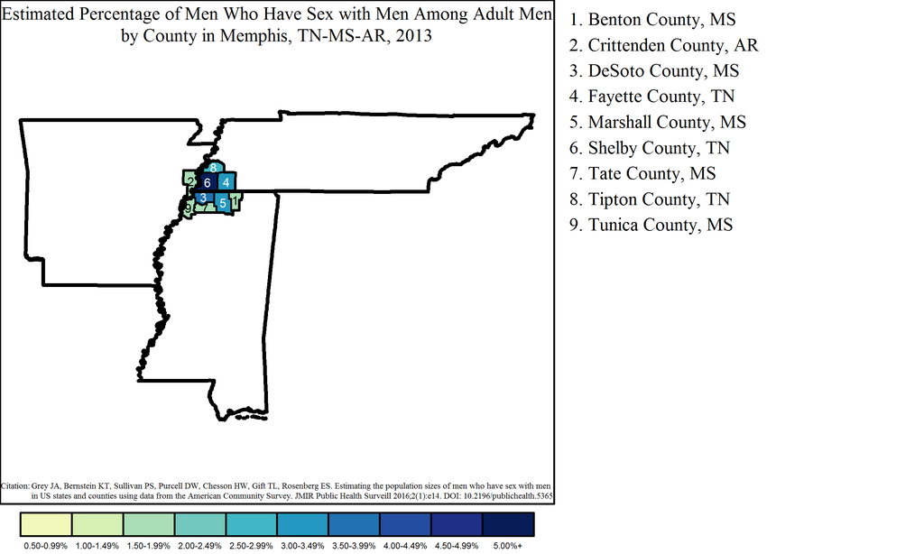